# Practical Machine Learning - Weight Lifting Exercises

## Reading in the dataset

First, I am loading the *caret* and *randomForest* libraries.

```r
library(caret)
library(randomForest)
```

I then read in the dataset and remove features (like usernames or timestamps) that are obviously irrelevant for a classification.

```r
pml <- read.csv('pml-training.csv')
pml <- subset(pml, select=-c(X,user_name,cvtd_timestamp,raw_timestamp_part_1,raw_timestamp_part_2,new_window,num_window))
```

There are also more parameters that are incomplete, and/or which I deem to be irrelevant.

```r
cn <- colnames(pml)
unsel_roll <- !grepl("_roll_", cn)
unsel_yaw <- !grepl("_yaw_", cn)
unsel_pitch <- !grepl("_pitch_", cn)
unsel_max <- !grepl("^max_", cn)
unsel_var <- !grepl("^var_", cn)
unsel_kur <- !grepl("^kurtosis_", cn)

pml2 <- subset(pml, select=cn[unsel_roll & unsel_yaw & unsel_pitch & unsel_max & unsel_var & unsel_kur])
```

## Splitting out Training and Test Datasets

I use a classic 60/40 split for the training and test set.

```r
inTrain <- createDataPartition(y=pml2$classe, p=0.6, list=FALSE)
training <- pml2[inTrain,]
testing <- pml2[-inTrain,]
```

## Training and Predicting

I use a random forest for the classification.

```r
ntree <- 300
fit <- randomForest(classe~., data=training, ntree=ntree)
```

Let us quantify the errors. First, the out-of-bag (OOB) error from the random tree:

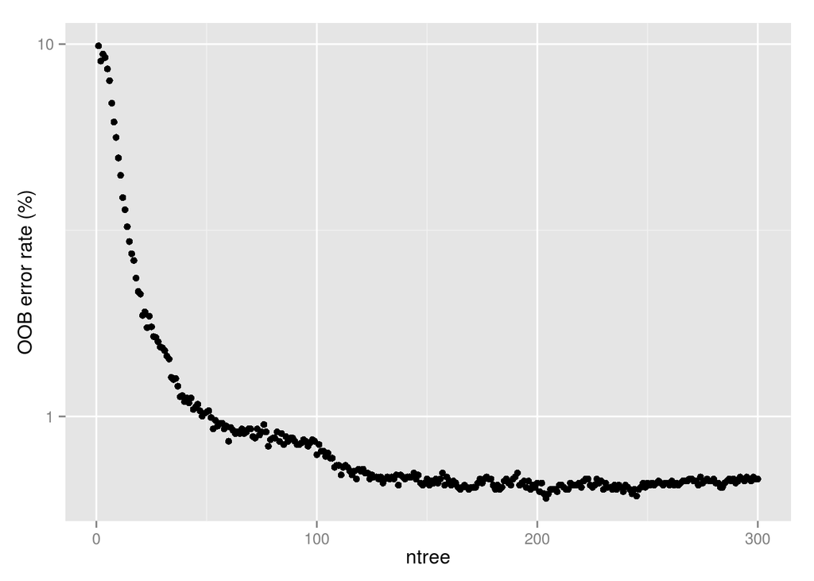

```r
oob.error.rate <- fit$err.rate[,1]*100
qplot(1:ntree, oob.error.rate, log='y', xlab='ntree', ylab='OOB error rate (%)')
```

As you see, the cutoff at 300 trees was chosen because I find convergence for the OOB error. This results in 0.68% of misclassified measurements when using 300 trees. Using random forests, there is no need for cross-validation, since the OOB error is already estimated by further dividing training set into several subsets.

Just for completeness, I will compare that to the out-of-sample error by using the predictor on the test set:

```r
correct <- sum(testing$classe == predict(fit, newdata=testing))
nTesting <- length(testing$classe)
oos.error.rate <- (nTesting-correct) / nTesting * 100
```

This gives us 0.76% of misclassified measurements as out-of-sample error, very similar to the OOB error.

## Acknowledgements

I would like to acknowledge the providers of this dataset:

Velloso, E.; Bulling, A.; Gellersen, H.; Ugulino, W.; Fuks, H. Qualitative Activity Recognition of Weight Lifting Exercises. Proceedings of 4th International Conference in Cooperation with SIGCHI (Augmented Human ’13) . Stuttgart, Germany: ACM SIGCHI, 2013.

http://groupware.les.inf.puc-rio.br/har#weight_lifting_exercises